# NMRphasing

Aixiang Jiang

2021-06-21

NMRphasing is an R package for NMR data phase error correction. Although this is targeting on 1D NMR data, it can be applied to 2D and 3D NMR data when a 1D NMR data file is phased at a time.

## I. NMRphasing installation

First of all, please make sure that you have R package MassSpecWavelet that NMRphasing depends on. Example code to install MassSpecWavelet is:

if (!requireNamespace(“BiocManager”, quietly = TRUE)) install.packages(“BiocManager”) BiocManager::install(“MassSpecWavelet”)

Now, let’s install NMRphasing from Github

```r
devtools :: install_github(repo = "ajiangsfu/NMRphasing",force = TRUE)
## if you do not have old versions of NMRphasing, please remove force = TRUE
```

## II. Data format

The input data format should be in one of the four formats: 1) a vector of absorption spectrum 2) a complex vector 3) a data matrix with two columns of spectrum data, the 1st column is for absorption spectrum, and 2nd column is for dispersion spectrum 4) a data frame with two columns of spectrum data, the 1st column is for absorption spectrum, and 2nd column is for dispersion spectrum

An example data from our multiple metabolite spike-in experiment can be loaded after you install NMRphasing.

```r
library(NMRphasing)
load(system.file("extdata", "fdat.rda", package = "NMRphasing"))
str(fdat)
```

```
## 'data.frame':    131072 obs. of  2 variables:
##  $ frequency_domain: cplx  -4049+252i -4338-148i -4573-216i ...
##  $ ppm             : num  14.8 14.8 14.8 14.8 14.8 ...
```

Here, fdat$frequency_domain is the data for the following illustration, which is a complex vector.

```r
## the following three lines are trying to avoid any possible conflict to the original data, and do not occupy extra space
psout = fdat
rm(fdat)
gc()
```

```
##           used (Mb) gc trigger (Mb) max used (Mb)
## Ncells  624939 33.4    1308550 69.9  1060730 56.7
## Vcells 1543597 11.8    8388608 64.0  2275232 17.4
```

```r
## in order to make comparison, absorption part can be extracted
psout$Observed_Absorption = Re(psout$frequency_domain)

library(ggpubr)
```

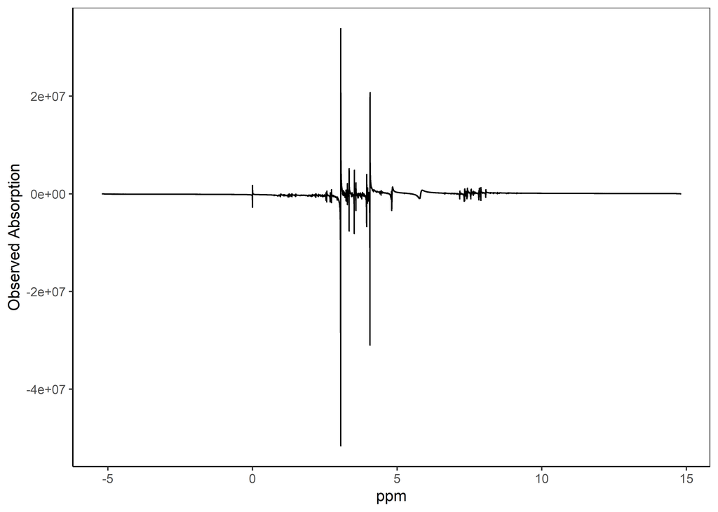

```r
p1 = ggplot(psout, aes(x = ppm, y = Observed_Absorption)) +
      geom_line() + theme_bw() + labs(y = "Observed Absorption") +
      theme(panel.grid.major = element_blank(), panel.grid.minor = element_blank(),
        panel.background = element_blank(), axis.line = element_line(colour = "black"))
p1
```

The observed absorption spectrum without phase error correction looks very bad.

## III. Example code

There are currently seven NMR phase error correction methods implemented in this package, they are:“SPC_DAOM”,“NLS”, “MPC_DAOM”, “MPC_EMP”, “SPC_EMP”, “SPC_AAM”, and “SPC_DSM”.

### 1. SPC_DAOM

This is to use the traditional single linear model approach for phase error correction but with our new optimization function to minimize difference between absolute area and ordinary area.

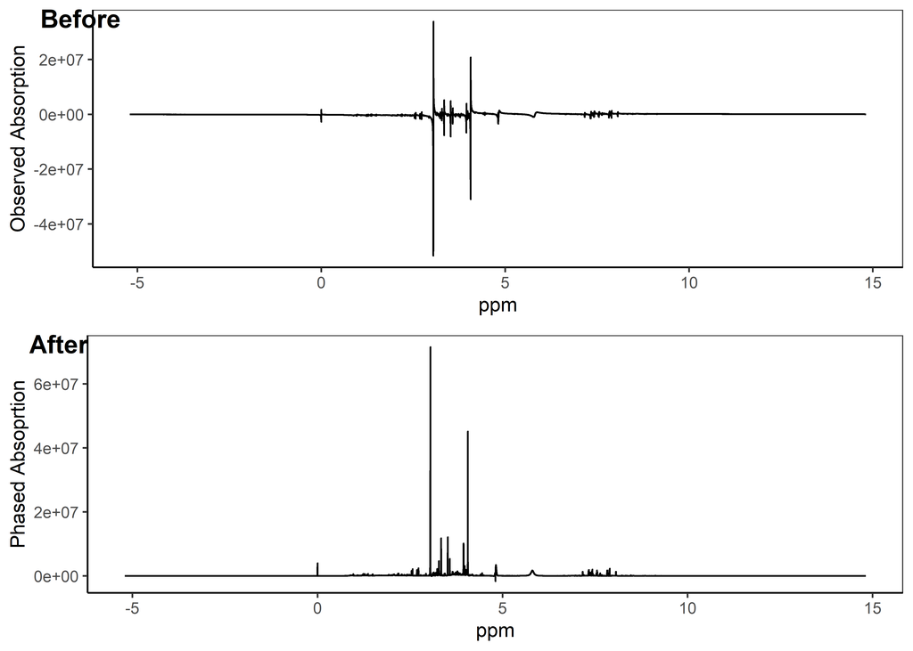

```r
psout$Phased_Absoprtion = NMRphasing(specDatIn = psout$frequency_domain, method = "SPC_DAOM")
### this step might take a couple of minutes

p2 = ggplot(psout, aes(x = ppm, y = Phased_Absoprtion)) +
      geom_line() + theme_bw() + labs(y = "Phased Absoprtion") +
        theme(panel.grid.major = element_blank(), panel.grid.minor = element_blank(),
        panel.background = element_blank(), axis.line = element_line(colour = "black"))
ggarrange(plotlist = list(p1,p2),labels = c("Before","After"),font.label =12,nrow = 2, ncol=1)
```

### 2. NLS

This is our new shrinkage method, which is the fastest phase error correction method since it does not involve any optimization step.

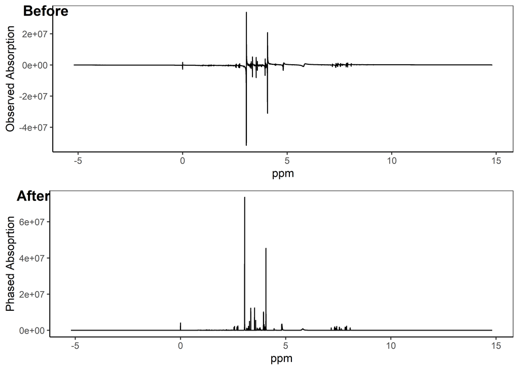

```r
psout$Phased_Absoprtion = NMRphasing(specDatIn = psout$frequency_domain, method = "NLS")
## this is the default method, therefore, the method setting can be ignored

p2 = ggplot(psout, aes(x = ppm, y = Phased_Absoprtion)) +
      geom_line() + theme_bw() + labs(y = "Phased Absoprtion") +
        theme(panel.grid.major = element_blank(), panel.grid.minor = element_blank(),
        panel.background = element_blank(), axis.line = element_line(colour = "black"))
ggarrange(plotlist = list(p1,p2),labels = c("Before","After"),font.label =12,nrow = 2, ncol=1)
```

### 3. MPC_DAOM

This is ti use our new multiple linear model approach for phase error correction with our new optimization function to minimize difference between absolute area and ordinal area.

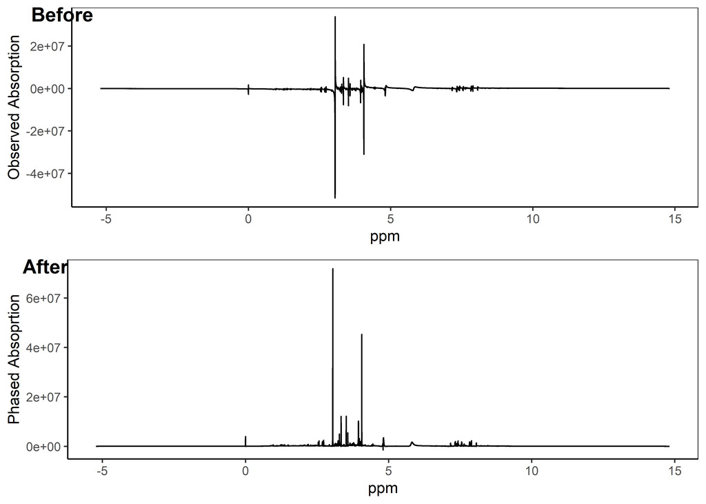

```r
psout$Phased_Absoprtion = NMRphasing(specDatIn = psout$frequency_domain, method = "MPC_DAOM")
## this step might take a couple of minutes

p2 = ggplot(psout, aes(x = ppm, y = Phased_Absoprtion)) +
      geom_line() + theme_bw() + labs(y = "Phased Absoprtion") +
        theme(panel.grid.major = element_blank(), panel.grid.minor = element_blank(),
        panel.background = element_blank(), axis.line = element_line(colour = "black"))
ggarrange(plotlist = list(p1,p2),labels = c("Before","After"),font.label =12,nrow = 2, ncol=1)
```

### 4. MPC_EMP

This is to apply our new multiple linear model approach for phase error correction based on an existing optimization function: entropy minimization with negative peak penalty.

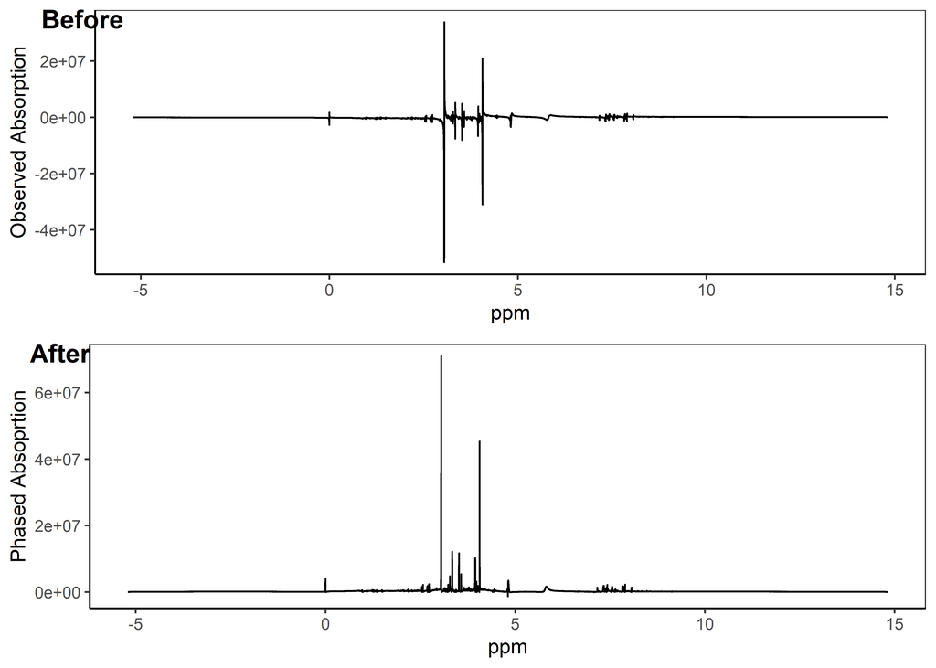

```r
psout$Phased_Absoprtion = NMRphasing(specDatIn = psout$frequency_domain, method = "MPC_EMP")
## this step might take a couple of minutes

p2 = ggplot(psout, aes(x = ppm, y = Phased_Absoprtion)) +
      geom_line() + theme_bw() + labs(y = "Phased Absoprtion") +
        theme(panel.grid.major = element_blank(), panel.grid.minor = element_blank(),
        panel.background = element_blank(), axis.line = element_line(colour = "black"))
ggarrange(plotlist = list(p1,p2),labels = c("Before","After"),font.label =12,nrow = 2, ncol=1)
```

### 5. SPC_EMP

This is an old phase error correction method based on the traditional single model approach targeting on an existing optimization function: entropy minimization with negative peak penalty.

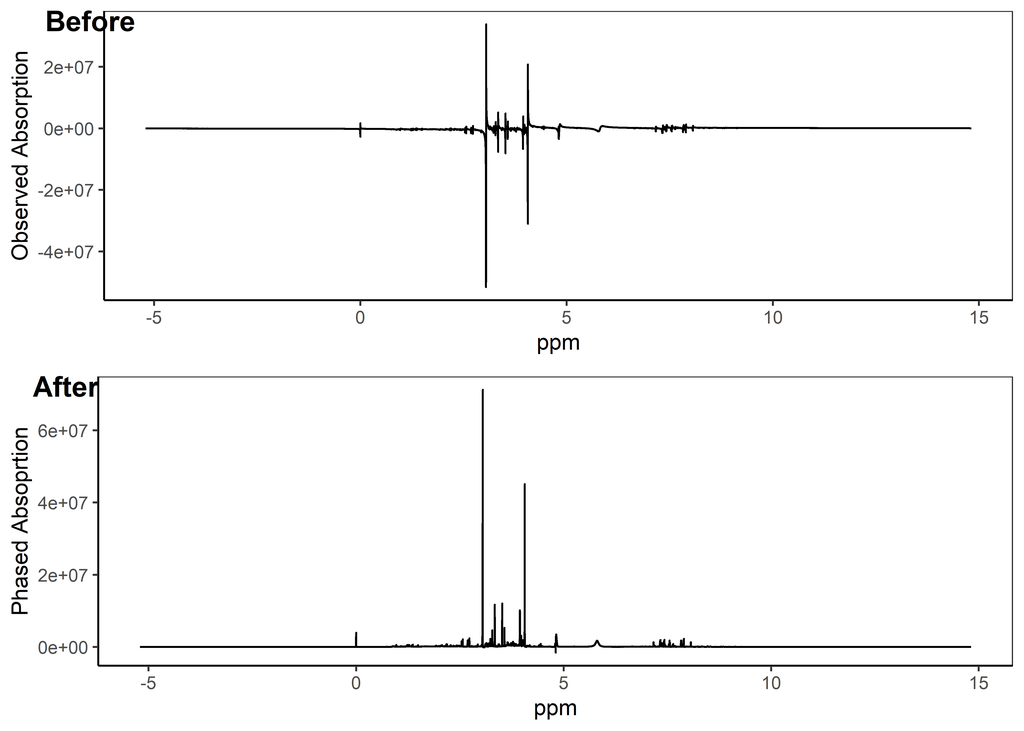

```r
psout$Phased_Absoprtion = NMRphasing(specDatIn = psout$frequency_domain, method = "SPC_EMP")
## this step might take a couple of minutes

p2 = ggplot(psout, aes(x = ppm, y = Phased_Absoprtion)) +
      geom_line() + theme_bw() + labs(y = "Phased Absoprtion") +
        theme(panel.grid.major = element_blank(), panel.grid.minor = element_blank(),
        panel.background = element_blank(), axis.line = element_line(colour = "black"))
ggarrange(plotlist = list(p1,p2),labels = c("Before","After"),font.label =12,nrow = 2, ncol=1)
```

### 6. SPC_AAM

This is an old phase error correction method based on the traditional single model approach with an existing optimization function: absolute area minimization.

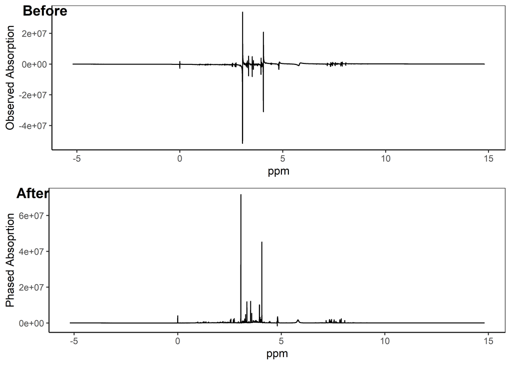

```r
psout$Phased_Absoprtion = NMRphasing(specDatIn = psout$frequency_domain, method = "SPC_AAM")
## this step might take a couple of minutes

p2 = ggplot(psout, aes(x = ppm, y = Phased_Absoprtion)) +
      geom_line() + theme_bw() + labs(y = "Phased Absoprtion") +
        theme(panel.grid.major = element_blank(), panel.grid.minor = element_blank(),
        panel.background = element_blank(), axis.line = element_line(colour = "black"))
ggarrange(plotlist = list(p1,p2),labels = c("Before","After"),font.label =12,nrow = 2, ncol=1)
```

### 7. SPC_DSM

This is an old phase error correction method based on the traditional single model approach with an existing optimization function: dispersion summation minimization.

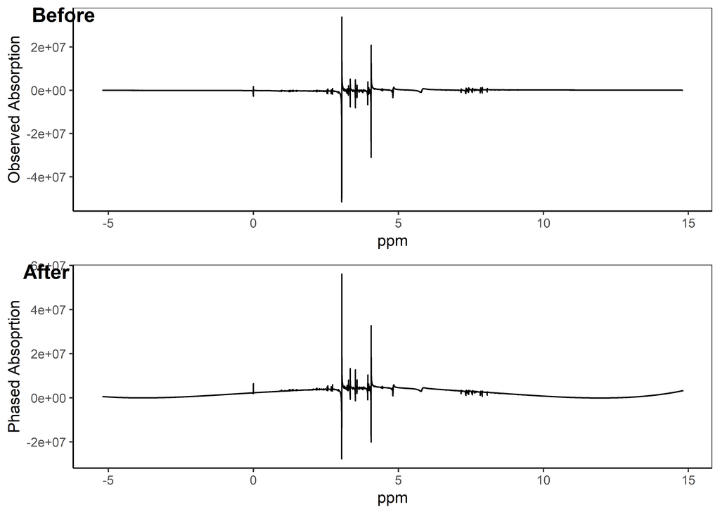

```r
psout$Phased_Absoprtion = NMRphasing(specDatIn = psout$frequency_domain, method = "SPC_DSM")
## this step might take a couple of minutes

p2 = ggplot(psout, aes(x = ppm, y = Phased_Absoprtion)) +
      geom_line() + theme_bw() + labs(y = "Phased Absoprtion") +
        theme(panel.grid.major = element_blank(), panel.grid.minor = element_blank(),
        panel.background = element_blank(), axis.line = element_line(colour = "black"))
ggarrange(plotlist = list(p1,p2),labels = c("Before","After"), font.label =12,nrow = 2, ncol=1)
```

SPC_DSM performs the worst on phase error correction based on our example data.

Side notes:

1. With a single CPU, it takes about 10 minutes to process all R code
2. Instruction files are also available within folder “docs”, there are in three formats: pdf, word, and html

## IV. NMRphasing R package general information

Version: 0.0.2

Author: Aixiang Jiang

Maintainer: Aixiang Jiang aijiang@bccrc.ca aixiang.jiang@pathology.ubc.ca

Depends: R (>= 4.0), baseline, splines, MassSpecWavelet

Suggests: knitr

VignetteBuilder: knitr